# 506 HW2

Author

Hongxuan An

Github link: https://github.com/ahongxuan/506HW # Question 1

## part (a) & (b)

```r
#' Implement this game using a loop over the die rolls.
#'
#' @param num_rolls number of dice to roll
#'
#' @return earned money
#' @export
#'
#' @examples
play_dice1 <- function(num_rolls){
  dollor <- 0
  for (i in 1:num_rolls){
    dollor <- dollor -2
    random_number <- sample(1:6, 1)
    if (random_number %% 2 == 0){
      dollor <- dollor + random_number
    }
  }
  return(dollor)
}

play_dice1(3)
```

```
[1] -6
```

```r
play_dice1(3000)
```

```
[1] 170
```

```r
#' Implement this game using built-in R vectorized functions.
#'
#' @param num_rolls number of dice to roll
#'
#' @return earned money
#' @export
#'
#' @examples
play_dice2 <- function(num_rolls){
  rolls <- sample(1:6, num_rolls, replace = TRUE)
  even_rolls <- rolls[rolls %% 2 == 0]
  dollors <- num_rolls*(-2) + sum(even_rolls)
  return(dollors)
}
play_dice2(3)
```

```
[1] -6
```

```r
play_dice2(3000)
```

```
[1] 136
```

```r
#' Implement this by collapsing the die rolls into a single table().
#'
#' @param num_rolls number of dice to roll
#'
#' @return earned money
#' @export
#'
#' @examples
play_dice3 <- function(num_rolls){
  rolls <- sample(1:6, num_rolls, replace = TRUE)
  roll_counts <- table(rolls)
  roll_counts_df <- as.data.frame(roll_counts)
  roll_counts_df$rolls <- as.numeric(roll_counts_df$rolls)
  dollors <- num_rolls*-2 +  sum((roll_counts_df$rolls[which(roll_counts_df$rolls %% 2 == 0)])*  (roll_counts_df$Freq[which(roll_counts_df$rolls %% 2 == 0)]))
  return(dollors)

}
play_dice3(3)
```

```
[1] -2
```

```r
play_dice3(3000)
```

```
[1] 20
```

```r
#' Implement this game by using one of the “apply” functions.
#'
#' @param num_rolls number of dice to roll
#'
#' @return earned money
#'
#' @export
#'
#' @examples
play_dice4 <- function(num_rolls){
  rolls <- sample(1:6, num_rolls, replace = TRUE)
  dollors <- num_rolls* -2 + sum(sapply(rolls, function(x) ifelse(x %% 2 == 0, x, 0), simplify = "'array"))
  return(dollors)
}
play_dice4(3)
```

```
[1] -4
```

```r
play_dice4(3000)
```

```
[1] 32
```

## part (c)

```r
set.seed(10)
play_dice1(3)
```

```
[1] -4
```

```r
set.seed(10)
play_dice2(3)
```

```
[1] -4
```

```r
set.seed(10)
play_dice4(3)
```

```
[1] -4
```

```r
set.seed(10)
play_dice3(3)
```

```
[1] -4
```

```r
set.seed(20)
play_dice1(3000)
```

```
[1] -88
```

```r
set.seed(20)
play_dice2(3000)
```

```
[1] -88
```

```r
set.seed(20)
play_dice3(3000)
```

```
[1] -88
```

```r
set.seed(20)
play_dice4(3000)
```

```
[1] -88
```

## part (d)

```r
library(microbenchmark)
small_input <- 100
  large_input <- 10000

  small_input_results <- microbenchmark(
    v1 = play_dice1(small_input),
    v2 = play_dice2(small_input),
    v3 = play_dice3(small_input),
    v4 = play_dice4(small_input),
    times = 1000  # Number of repetitions
  )
  large_input_results <- microbenchmark(
    v1 = play_dice1(large_input),
    v2 = play_dice2(large_input),
    v3 = play_dice3(large_input),
    v4 = play_dice4(large_input),
    times = 1000  # Number of repetitions
  )

list <- list(small_input_results, large_input_results)
list
```

```
[[1]]
Unit: microseconds
 expr     min      lq       mean   median       uq      max neval cld
   v1 228.370 243.417 278.488769 253.2365 264.2450 4326.935  1000 a
   v2   5.453   6.314   6.836012   6.6010   6.9700   40.426  1000  b
   v3  99.179 104.140 114.817712 106.1285 109.3060 1947.500  1000   c
   v4  94.423  98.154 106.080038  99.7120 102.7665 1744.796  1000   c

[[2]]
Unit: microseconds
 expr       min         lq       mean     median         uq       max neval
   v1 25290.727 26793.0695 28166.9207 27513.3165 28762.9760 67831.507  1000
   v2   287.533   300.8170   313.4714   307.2335   316.1510  2406.249  1000
   v3   581.052   648.4355   698.1068   681.2355   718.5865  3228.586  1000
   v4  8965.388  9251.5885 10289.5342 10071.1785 10881.7690 29506.101  1000
  cld
 a
  b
   c
    d
```

## part (e)

Yes, it’s a fair game.

To determine whether this dice game is fair or not, we can use a Monte Carlo simulation to simulate the game many times and analyze the outcomes. A fair game is one where the expected value of winnings/losses is zero over many plays.

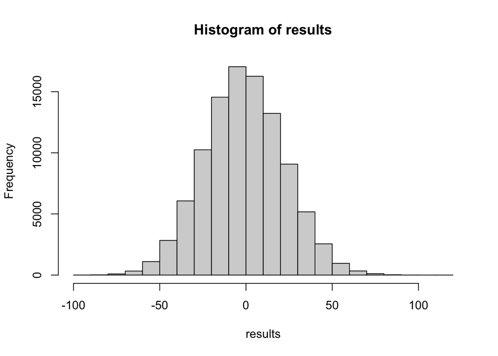

```r
num_simulations <- 100000

# Simulate the game multiple times
results <- replicate(num_simulations, play_dice2(100))

hist(results)
```

```r
# Calculate the mean winnings/losses
mean_winnings <- mean(results)

# Print the mean winnings/losses
print(mean_winnings)
```

```
[1] -0.00786
```

The result is quit close to 0, which means you neither win nor lose much money when playing the game, which indicates that the game is fairly balanced.

# Question 2

## part (a)

```r
cars <- read.csv("/Users/an/Documents/Umich/stats 506/cars.csv")
colnames(cars) <- c("Height", "Length","Width", "Driveline", "E_Type", "Hybrid", "Num_Gears", "Transmission", "C_mpg", "F_Tpye", "MPG", "Calssification", "ID", "Make", "M_Year", "Year", "Horsepower", "Torque")
head(cars)
```

```
  Height Length Width         Driveline
1    140    143   202   All-wheel drive
2    140    143   202 Front-wheel drive
3    140    143   202 Front-wheel drive
4    140    143   202   All-wheel drive
5    140    143   202   All-wheel drive
6     91     17    62   All-wheel drive
                                        E_Type Hybrid Num_Gears
1         Audi 3.2L 6 cylinder 250hp 236ft-lbs   True         6
2 Audi 2.0L 4 cylinder 200 hp 207 ft-lbs Turbo   True         6
3 Audi 2.0L 4 cylinder 200 hp 207 ft-lbs Turbo   True         6
4 Audi 2.0L 4 cylinder 200 hp 207 ft-lbs Turbo   True         6
5 Audi 2.0L 4 cylinder 200 hp 207 ft-lbs Turbo   True         6
6        Audi 3.2L 6 cylinder 265hp 243 ft-lbs   True         6
                    Transmission C_mpg   F_Tpye MPG         Calssification
1 6 Speed Automatic Select Shift    18 Gasoline  25 Automatic transmission
2 6 Speed Automatic Select Shift    22 Gasoline  28 Automatic transmission
3                 6 Speed Manual    21 Gasoline  30    Manual transmission
4 6 Speed Automatic Select Shift    21 Gasoline  28 Automatic transmission
5 6 Speed Automatic Select Shift    21 Gasoline  28 Automatic transmission
6                 6 Speed Manual    16 Gasoline  27    Manual transmission
                          ID Make       M_Year Year Horsepower Torque
1           2009 Audi A3 3.2 Audi 2009 Audi A3 2009        250    236
2      2009 Audi A3 2.0 T AT Audi 2009 Audi A3 2009        200    207
3         2009 Audi A3 2.0 T Audi 2009 Audi A3 2009        200    207
4 2009 Audi A3 2.0 T Quattro Audi 2009 Audi A3 2009        200    207
5 2009 Audi A3 2.0 T Quattro Audi 2009 Audi A3 2009        200    207
6           2009 Audi A5 3.2 Audi 2009 Audi A5 2009        265    243
```

## part (b)

```r
cars_gasoline <- cars[which(cars$F_Tpye == "Gasoline"),]
```

## part (c)

```r
cars_gasoline$Year_Measurement <- as.factor(cars_gasoline$Year)


mod <- lm(MPG~ Horsepower + Torque + Height + Length + Width + Year_Measurement, data = cars_gasoline)
summary(mod)
```

```
Call:
lm(formula = MPG ~ Horsepower + Torque + Height + Length + Width +
    Year_Measurement, data = cars_gasoline)

Residuals:
    Min      1Q  Median      3Q     Max
-10.824  -2.550  -0.452   2.372 202.639

Coefficients:
                       Estimate Std. Error t value Pr(>|t|)
(Intercept)          32.2926630  0.7225982  44.690  < 2e-16 ***
Horsepower            0.0163556  0.0022772   7.182 7.96e-13 ***
Torque               -0.0507425  0.0022030 -23.034  < 2e-16 ***
Height                0.0099079  0.0011267   8.794  < 2e-16 ***
Length                0.0017290  0.0008836   1.957   0.0504 .
Width                -0.0003343  0.0009045  -0.370   0.7117
Year_Measurement2010 -0.4539681  0.6768246  -0.671   0.5024
Year_Measurement2011  0.1711016  0.6757043   0.253   0.8001
Year_Measurement2012  1.3029279  0.6810076   1.913   0.0558 .
---
Signif. codes:  0 '***' 0.001 '**' 0.01 '*' 0.05 '.' 0.1 ' ' 1

Residual standard error: 4.602 on 4582 degrees of freedom
Multiple R-squared:  0.4192,    Adjusted R-squared:  0.4182
F-statistic: 413.3 on 8 and 4582 DF,  p-value: < 2.2e-16
```

## part (d)

```r
# Fit a model with the interaction term
mod_interaction <- lm(MPG ~ Horsepower * Torque + Height + Length + Width + Year_Measurement, data = cars_gasoline)
summary(mod_interaction)
```

```
Call:
lm(formula = MPG ~ Horsepower * Torque + Height + Length + Width +
    Year_Measurement, data = cars_gasoline)

Residuals:
    Min      1Q  Median      3Q     Max
-11.109  -2.313  -0.258   2.062 203.540

Coefficients:
                       Estimate Std. Error t value Pr(>|t|)
(Intercept)           4.219e+01  7.930e-01  53.199  < 2e-16 ***
Horsepower           -1.666e-02  2.539e-03  -6.563 5.84e-11 ***
Torque               -8.606e-02  2.533e-03 -33.972  < 2e-16 ***
Height                6.560e-03  1.070e-03   6.133 9.32e-10 ***
Length                1.777e-03  8.318e-04   2.136   0.0327 *
Width                -1.169e-03  8.521e-04  -1.372   0.1700
Year_Measurement2010 -5.628e-01  6.372e-01  -0.883   0.3771
Year_Measurement2011  7.254e-02  6.361e-01   0.114   0.9092
Year_Measurement2012  1.197e+00  6.411e-01   1.867   0.0619 .
Horsepower:Torque     1.124e-04  4.628e-06  24.276  < 2e-16 ***
---
Signif. codes:  0 '***' 0.001 '**' 0.01 '*' 0.05 '.' 0.1 ' ' 1

Residual standard error: 4.333 on 4581 degrees of freedom
Multiple R-squared:  0.4854,    Adjusted R-squared:  0.4844
F-statistic: 480.1 on 9 and 4581 DF,  p-value: < 2.2e-16
```

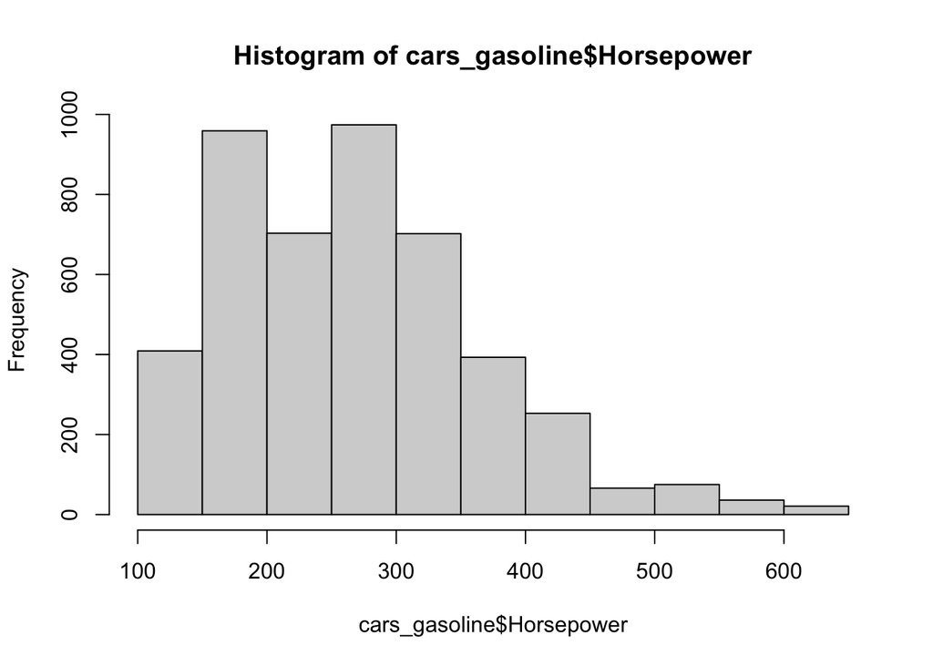

```r
library(interactions)
hist(cars_gasoline$Horsepower)
```

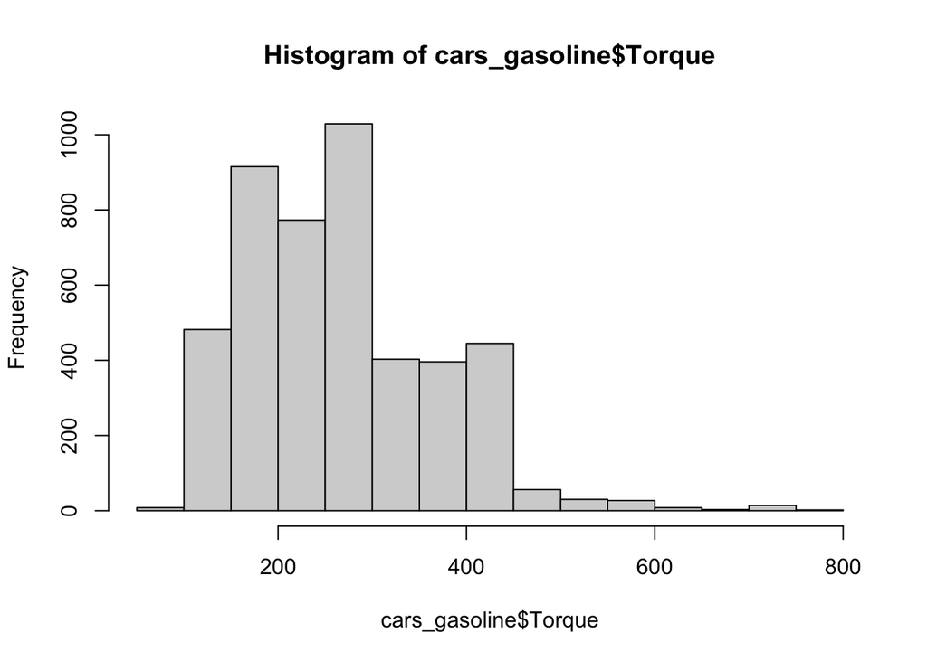

```r
hist(cars_gasoline$Torque)
```

```r
summary(cars_gasoline$Horsepower)
```

```
   Min. 1st Qu.  Median    Mean 3rd Qu.    Max.
  100.0   185.0   263.0   267.5   317.0   638.0
```

```r
summary(cars_gasoline$Torque)
```

```
   Min. 1st Qu.  Median    Mean 3rd Qu.    Max.
   98.0   177.0   257.0   267.2   332.0   774.0
```

I’d like to choose mean, median, 3rd Qu.

```r
table(cars_gasoline$Year_Measurement)
```

```
2009 2010 2011 2012
  48 1633 1794 1116
```

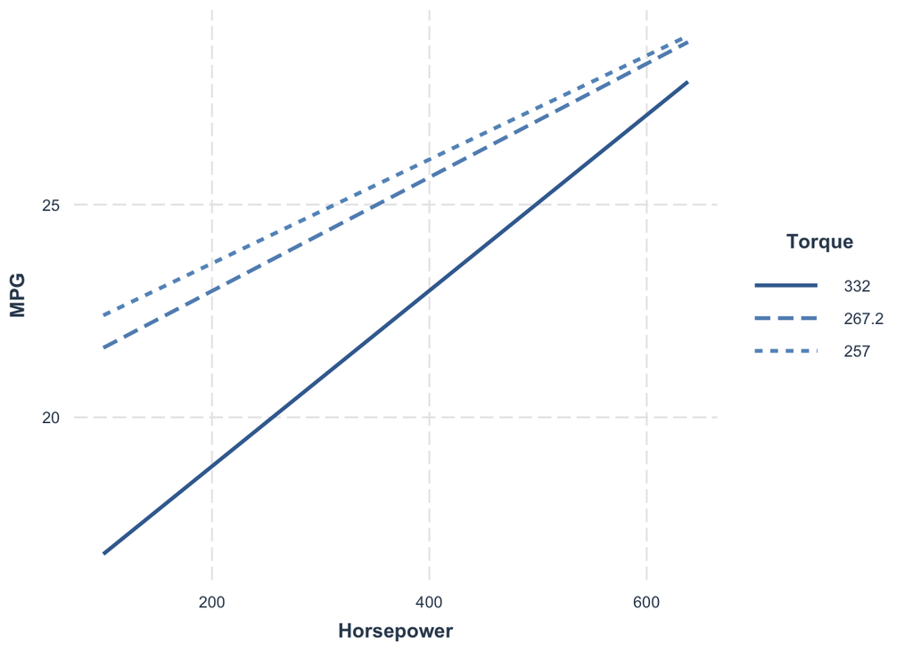

```r
interact_plot(mod_interaction, pred = Horsepower, modx = Torque, modx.values = c(257.0, 267.2,332.0), at=list(Year_Measurement='2011'))
```

## part (e)

```r
x <- model.matrix(MPG ~ Horsepower * Torque + Height + Length + Width + Year_Measurement, data = cars_gasoline)

y <- cars_gasoline$MPG

beta <- solve(t(x) %*% x) %*% t(x) %*% y
beta
```

```
                              [,1]
(Intercept)          42.1879478687
Horsepower           -0.0166633227
Torque               -0.0860592704
Height                0.0065603903
Length                0.0017767232
Width                -0.0011694485
Year_Measurement2010 -0.5627857770
Year_Measurement2011  0.0725356431
Year_Measurement2012  1.1970329986
Horsepower:Torque     0.0001123567
```

# Question 3

## part (a)

STATA INPUT:

```stata
import delimited ///
"/Users/an/Documents/Umich/stats 506/cars.csv", clear


rename dimensionsheight height
rename dimensionslength length
rename dimensionswidth width
rename engineinformationdriveline driveline
rename engineinformationenginetype engine
rename engineinformationhybrid hybrid
rename engineinformationnumberofforward forward
rename engineinformationtransmission trans
rename fuelinformationcitympg cmpg
rename fuelinformationfueltype fuel
rename fuelinformationhighwaympg hmpg
rename identificationclassification classification
rename identificationid id
rename identificationmake make
rename identificationmodelyear myear
rename identificationyear year
rename engineinformationenginestatistic horsepower
rename v18 torque
```

## part (b)

```stata
keep if fuel == "Gasoline"
```

## part (c)

```stata
regress hmpg horsepower torque height length width i.year
```

Source | SS df MS Number of obs = 4,591

-------------+---------------------------------- F(8, 4582) = 413.35

Model | 70043.6695 8 8755.45869 Prob > F = 0.0000

Residual | 97055.298 4,582 21.1818634 R-squared = 0.4192

-------------+---------------------------------- Adj R-squared = 0.4182

Total | 167098.968 4,590 36.4050038 Root MSE = 4.6024

------------------------------------------------------------------------------

hmpg | Coefficient Std. err. t P>|t| [95% conf. interval]

-------------+----------------------------------------------------------------

horsepower | .0163556 .0022772 7.18 0.000 .0118913 .02082

torque | -.0507425 .002203 -23.03 0.000 -.0550614 -.0464236

height | .0099079 .0011267 8.79 0.000 .007699 .0121168

length | .001729 .0008836 1.96 0.050 -3.36e-06 .0034613

width | -.0003343 .0009045 -0.37 0.712 -.0021075 .0014388

|

year |

2010 | -.4539681 .6768246 -0.67 0.502 -1.78087 .8729342

2011 | .1711016 .6757043 0.25 0.800 -1.153604 1.495808

2012 | 1.302928 .6810076 1.91 0.056 -.0321751 2.638031

|

_cons | 32.29266 .7225982 44.69 0.000 30.87602 33.7093

------------------------------------------------------------------------------

## part (d)

```stata
regress hmpg c.horsepower##c.torque height length width i.year

margins, at(horsepower=(100(5)638) torque=(257,267.2,332) year=2011)
marginsplot
```

Source | SS df MS Number of obs = 4,591

-------------+---------------------------------- F(9, 4581) = 480.07

Model | 81105.8715 9 9011.76351 Prob > F = 0.0000

Residual | 85993.096 4,581 18.7716865 R-squared = 0.4854

-------------+---------------------------------- Adj R-squared = 0.4844

Total | 167098.968 4,590 36.4050038 Root MSE = 4.3326

---------------------------------------------------------------------------------------

hmpg | Coefficient Std. err. t P>|t| [95% conf. interval]

----------------------+----------------------------------------------------------------

horsepower | -.0166633 .0025388 -6.56 0.000 -.0216406 -.011686

torque | -.0860593 .0025333 -33.97 0.000 -.0910257 -.0810928

|

c.horsepower#c.torque | .0001124 4.63e-06 24.28 0.000 .0001033 .0001214

|

height | .0065604 .0010696 6.13 0.000 .0044634 .0086573

length | .0017767 .0008318 2.14 0.033 .0001459 .0034075

width | -.0011694 .0008521 -1.37 0.170 -.00284 .0005011

|

year |

2010 | -.5627858 .6371716 -0.88 0.377 -1.811949 .6863777

2011 | .0725356 .6361142 0.11 0.909 -1.174555 1.319626

2012 | 1.197033 .6411085 1.87 0.062 -.0598488 2.453915

|

_cons | 42.18795 .7930274 53.20 0.000 40.63323 43.74266

---------------------------------------------------------------------------------------

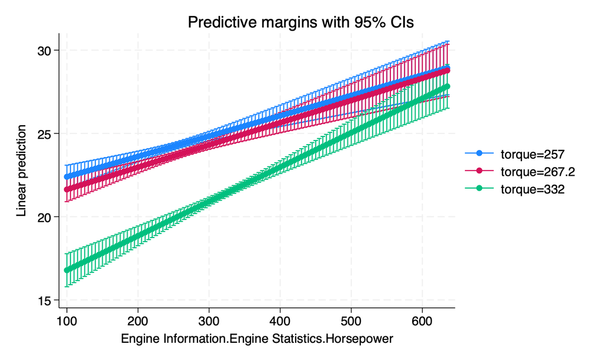

interaction plot